# Quantifying the cost savings of global solar photovoltaic supply chains

John Paul Helveston, **Gang He***, & Michael Davidson

November 10, 2022

## Speed and scale

10 $\times$ today’s level by 2050

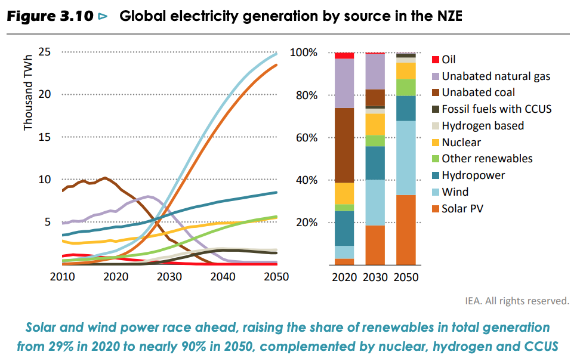

Source: IEA (2021)

## Cost is key for renewables to compete

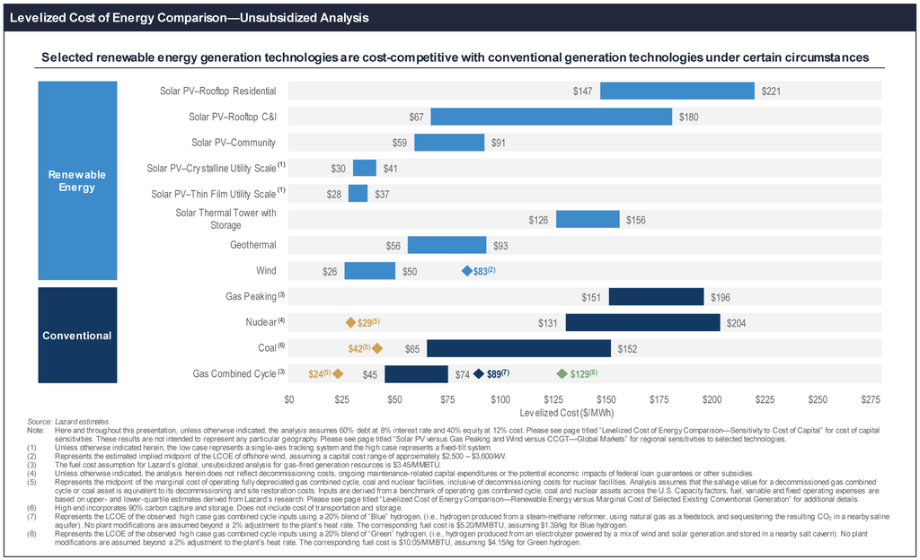

Source: [Lazard LCOE 15.0](https://www.lazard.com/perspective/levelized-cost-of-energy-levelized-cost-of-storage-and-levelized-cost-of-hydrogen/)

## PV is getting cheap

Between 2010 - 2020, global levelized cost of energy (LCOE) of utility-scale solar PV fell by 85%

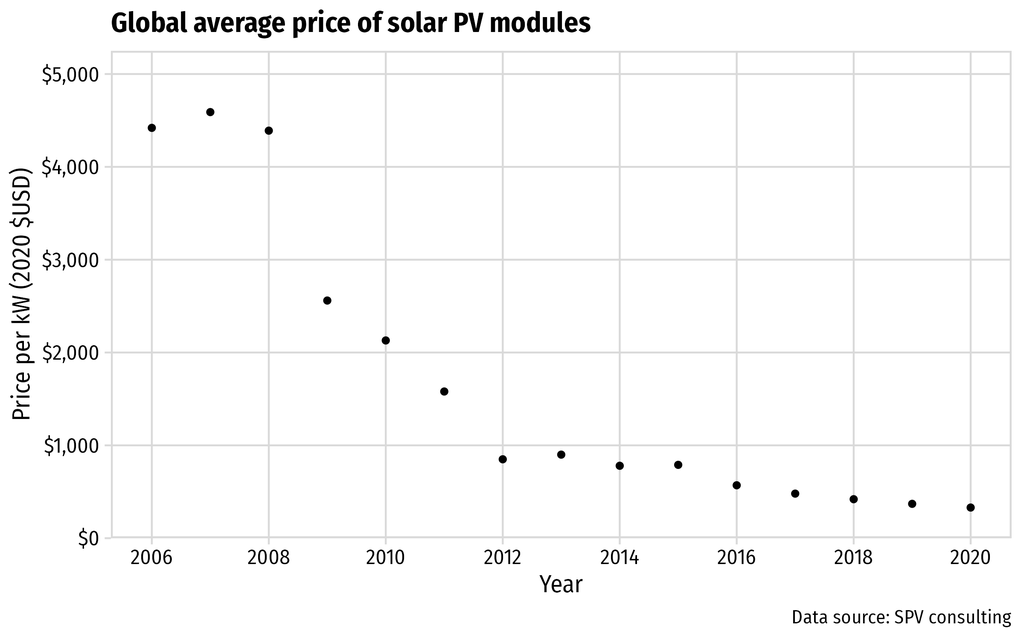

## Partly thanks to the global supply chain dominated by China

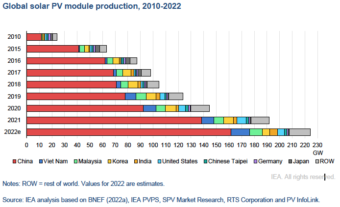

## China is manufacturing leader in almost every sector

| Technology | Scale |
| --- | --- |
| Solar Panels | From 1% to 78% (2001 - 2021) |
| Wind Turbines | 1/3 of global supply (2020) |
| Electric Vehicles | 51% of global sales (2021) |
| Lithium-ion Batteries | 70% of global production (76% by 2025) |
| Nuclear Reactors | From 45 to 88 plants by 2030 |

## China’s “gift to the world”

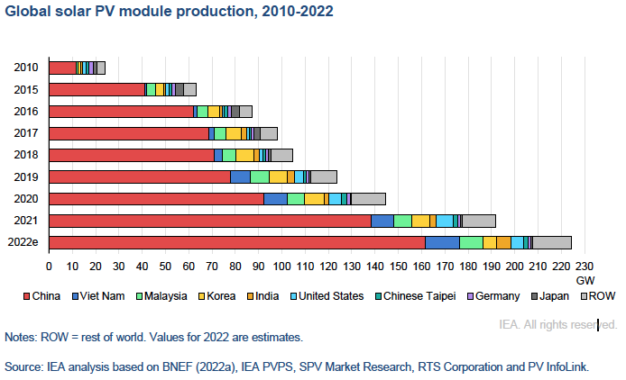

China comprises ~78% of global PV production in 2021

**Response**:

- US and EU tariffs on imported Chinese PV panels
- June 2022: Biden Administration invokes the Defense Production Act to accelerate US PV manufacturing

## Diversifying supply chain, domestic manufacuring

Rationale:

- Localizing benefits in terms of growth, employment, and trade surpluses
- Supply chain resilience to disruptions

Approach:

- Restricting the free flow of products, capital, talent, and innovation
- Tariffs, trade barriers, industrial regulations/policy

## **Research Question**

- What are the costs of national versus global supply chains?
- What does it mean for achieving climate goals?

## Learning curve model

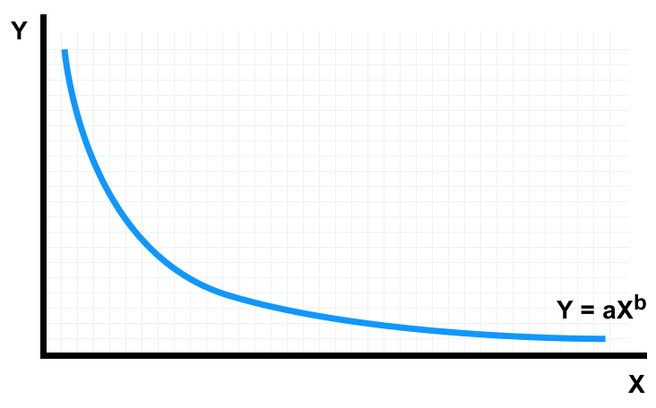

Source: Yelle (1979)

## Learning curve model

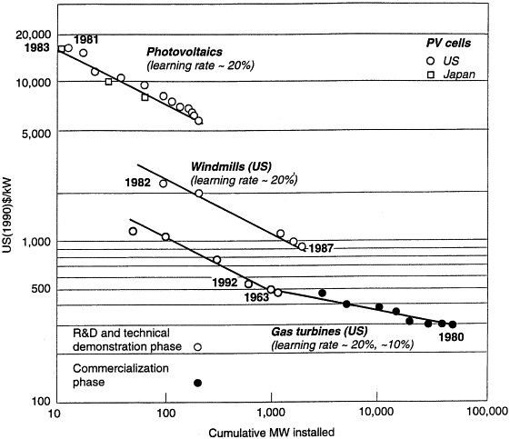

In context of solar PV:

- X: Cumulative installed cap.
- Y: Price per kW

Log transformation:

$$\ln Y = \ln a + b \ln X$$
Learning rate:

$$lr = 1 - 2^{b}$$

Source: Grübler, Nakićenović, and Victor (1999)

## Two-factor learning curve model:

$$\ln p_{it} = \ln \alpha_i + \beta_i \ln q_{t} + \gamma_i \ln s_{t} + \varepsilon_{it}$$

price ($ / kW) = intercept + installed capacity + silicon price

for country *i* and year *t*

Learning rate:

$$L_i = 1 - 2^{\beta_i}$$

## Data Sources

| Country | Data | Source |
| --- | --- | --- |
| Global | Installed PV capacity and prices | International Renewable Energy Agency (IRENA) |
| U.S. | Installed capacity | Solar Energy Industries Association (SEIA) |
| U.S. | Module prices | Lawrence Berkeley National Laboratory (LBNL) & National Renewable Energy Laboratory (NREL) |
| China | Installed capacity & module prices | Energy Research Institute (ERI) & China Photovoltaic Industry Association |
| Germany | Installed capacity | IRENA |
| Germany | Module prices | Fraunhofer ISE50 |

Note: All prices are in $2020 USD; inflation adjustments from IMF, exchange rates from Federal Reserve Bank.

## “National Markets” Counterfactual Scenario

**Assumption**: learning-related price decreases in country *i* in year *t* are derived from incrementally more nationally-installed PV capacity

$$q_t - q_{t-1} = \lambda_t(q_{i,t} - q_{i,t-1}) + (1 - \lambda_t) (q_{i,t} - q_{i,t-1}) + (1 - \lambda_t) (q_{j,t} - q_{j,t - 1})$$

$(q_{i,t} - q_{i,t-1})$: Amount installed in country *i*

$(q_{j,t} - q_{j,t-1})$: Amount installed in all other countries

$$q_t - q_{t-1} = (q_{i,t} - q_{i,t-1}) + (1 - \lambda_t) (q_{j,t} - q_{j,t - 1})$$

Source: Helveston, He, and Davidson (2022)

## Global Markets vs. National Markets

**Global markets**

$\lambda_t = 0$

Capacity from all countries

$$(q_{i,t} - q_{i,t-1}) + (q_{j,t} - q_{j,t - 1})$$

**National markets**

$\lambda_t = 1$

Capacity only from country *i*

$$(q_{i,t} - q_{i,t-1})$$

$\lambda_t$ -> 1 over 10-year period

Source: Helveston, He, and Davidson (2022)

## Model results

[output not shown]

Asterisks indicate the level of significance: *5%; **1%; ***0.1%.

## A National-market Strategy Would Increase the Costs

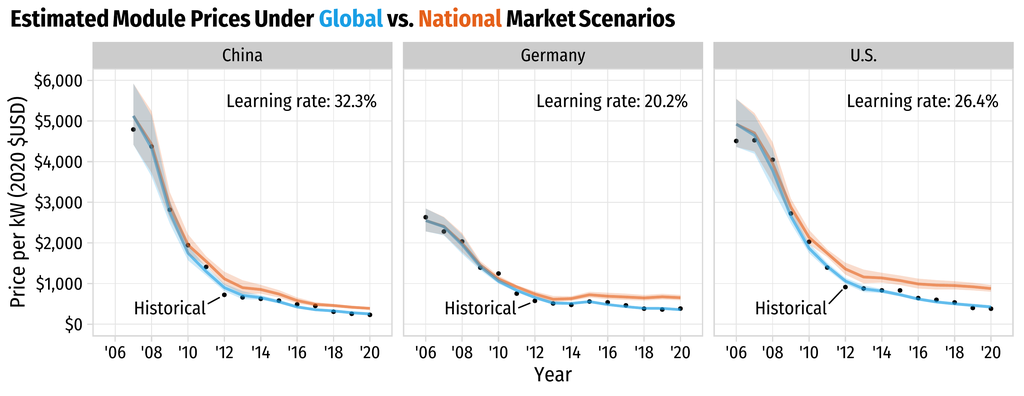

**Higher prices in 2020**:

- 54% higher in China ($387 versus $250 per kW)
- 83% in higher Germany ($652 versus $357 per kW)
- 107% higher in the U.S. ($877 versus $424 per kW)

Source: Helveston, He, and Davidson (2022)

## Total Savings by Global Supply Chain: $67 billion ($50 - $84 billion)

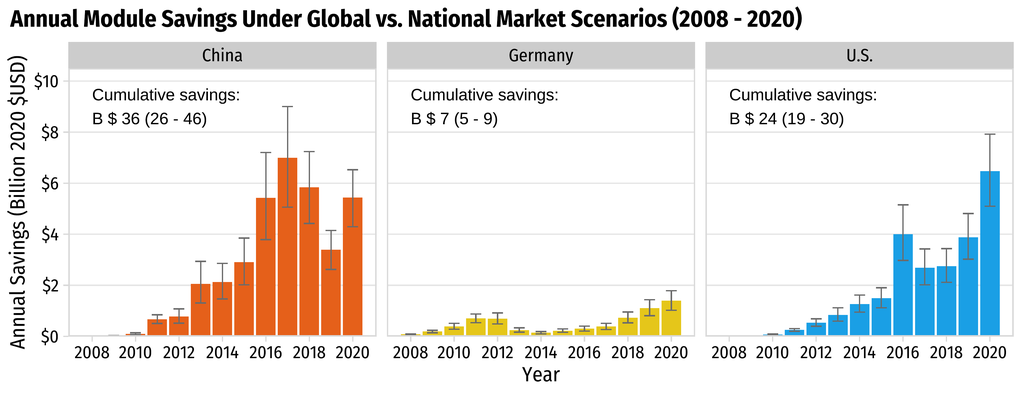

Source: Helveston, He, and Davidson (2022)

## Future projections

Two future projection scenarios out to 2030

#### National Trends (NT)

| Country | 2030 Target (GW) | Implied CAGR |
| --- | --- | --- |
| U.S. | 295 | 12% |
| China | 750 | 12% |
| Germany | 103 | 7% |
| World | 2,115 | 11% |

#### Sustainable Development (SD)

| Country | 2030 Target (GW) | Implied CAGR |
| --- | --- | --- |
| U.S. | 411 | 16% |
| China | 1,106 | 17% |
| Germany | 147 | 11% |
| World | 3,125 | 16% |

(Sustainable Development Scenario in the 2020 IEA World Energy Outlook)

Source: Helveston, He, and Davidson (2022)

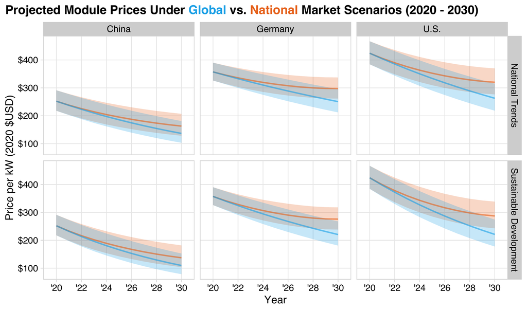

## Higher prices in 2030

#### National Trends (NT)

**~20% higher in each country**

- China: $162 versus $135 per kW
- Germany: $298 versus $251 per kW
- U.S.: $320 versus $262 per kW

#### Sustainable Development (SD)

**~25-30% higher in each country**

- China: $136 versus $108 per kW
- Germany: $276 versus $221 per kW
- U.S.: $287 versus $221 per kW

For comparison, NREL’s 2021 Annual Technology Baseline report predicts $170, $190, and $320 / kW by 2030 in advanced, moderate, and conservative improvement scenarios.

Source: Helveston, He, and Davidson (2022)

## Future Savings

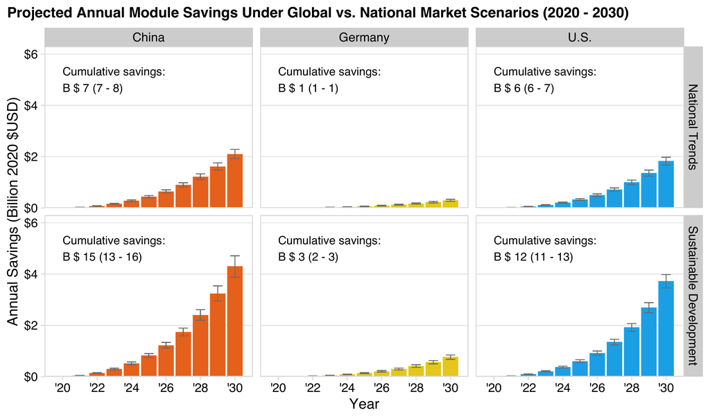

Source: Helveston, He, and Davidson (2022)

## Take home messages

- Globalized supply chain has saved solar installers in the U.S.($24B), Germany($7B), and China ($36B), total $67B from 2008 to 2020
  - China’s mass production accelerates the cost decline
  - China also benefits from the global supply chains
- Solar prices will be 20-30% higher in 2030 if countries move to produce domestically
  - Confronting climate change relies on international collaboration

## Open science

[figure not shown]

#### Paper link

https://www.nature.com/articles/s41586-022-05316-6

#### Data and code

https://github.com/jhelvy/solar-learning-2021

#### Sensitivity analysis app

https://jhelvy.shinyapps.io/solar-learning-2021/

#### More about the paper

https://drganghe.github.io/posts/2022-10-nature-cost-savings-of-global-solar-pv-value-chains/

## Contacts

John Helveston  
George Washington University  
jph@gwu.edu  
https://www.jhelvy.com

[figure not shown]

Gang He  
Stony Brook University  
gang.he@stonybrook.edu  
https://www.ganghe.net

[figure not shown]

Michael Davidson  
University of California, San Diego  
mrdavidson@ucsd.edu  
https://mdavidson.org

[figure not shown]

## Back up slides

## No transition time: historical prices

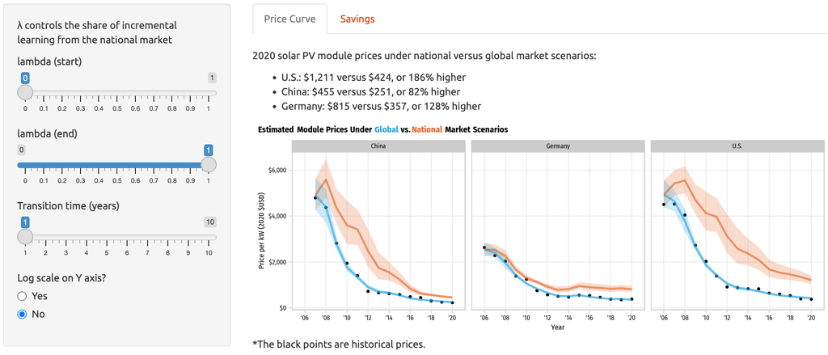

Source: Helveston, He, and Davidson (2022)

## No transition time: historical savings

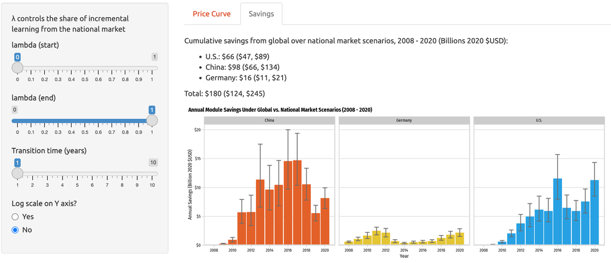

Source: Helveston, He, and Davidson (2022)

## No transition time: future prices

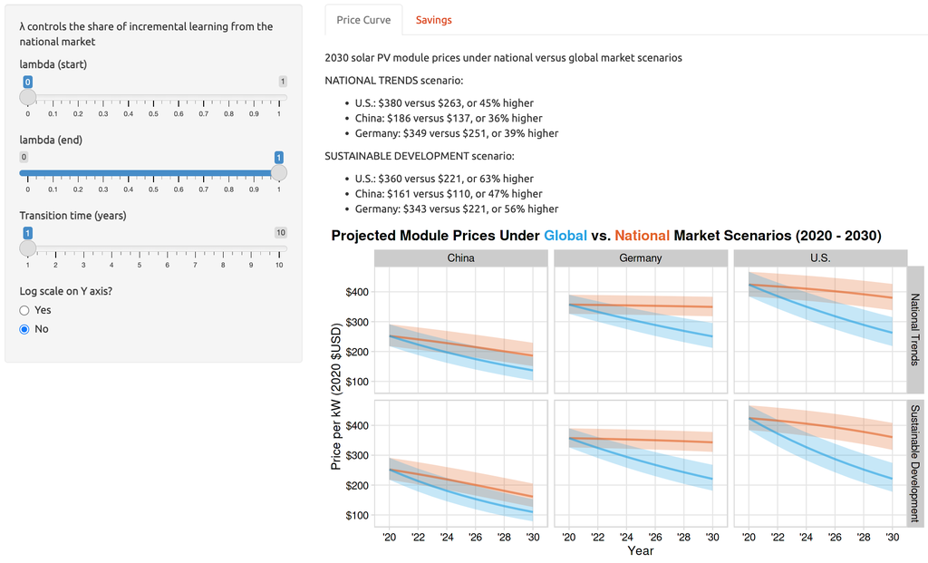

Source: Helveston, He, and Davidson (2022)

## No transition time: future savings

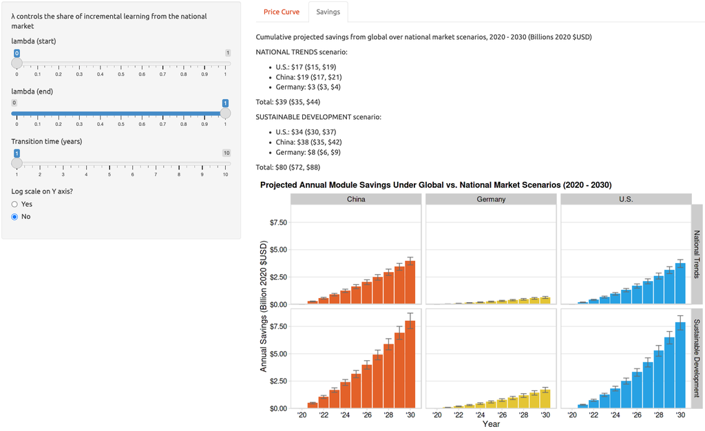

Source: Helveston, He, and Davidson (2022)

## Drivers of learning

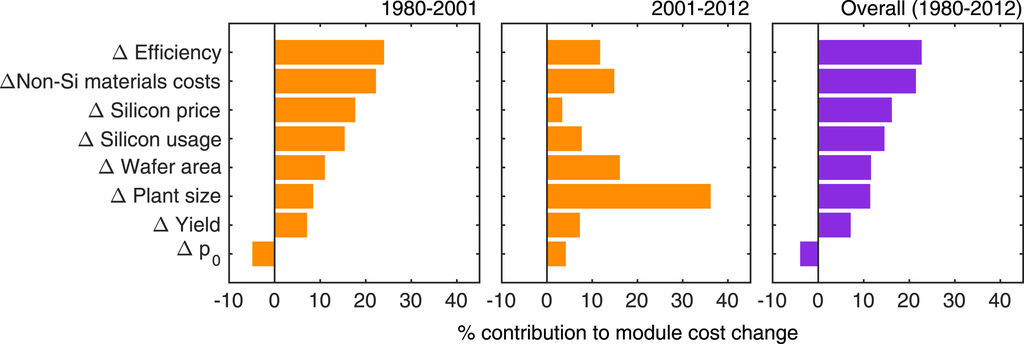

Source: Kavlak, McNerney, and Trancik (2018)

## Source of learning

Learning by doing

- Economy of scale
- Economy of scope

Learning by researching

Source: Zheng and Kammen (2014), Meng et al. (2021), Zhang et al. (2022)

## Historical silicon prices

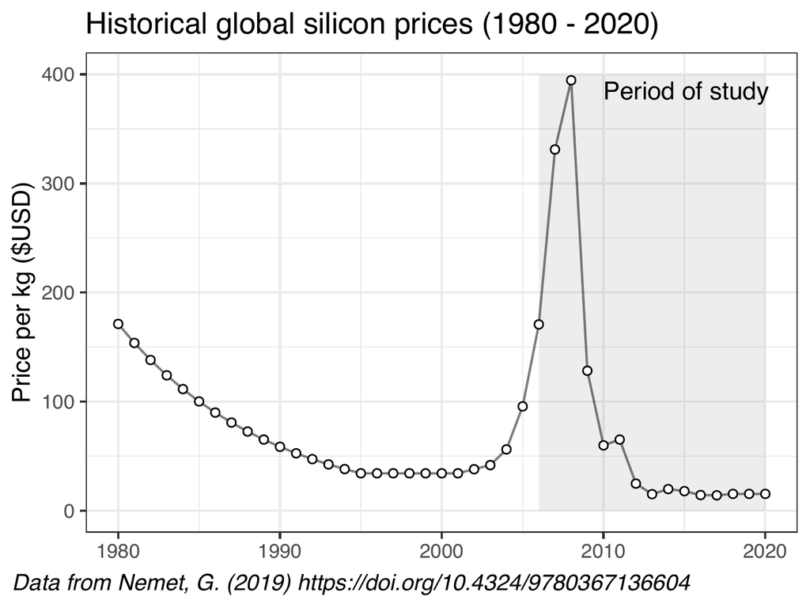

Source: Helveston, He, and Davidson (2022)

## Relation between $\lambda$ and p

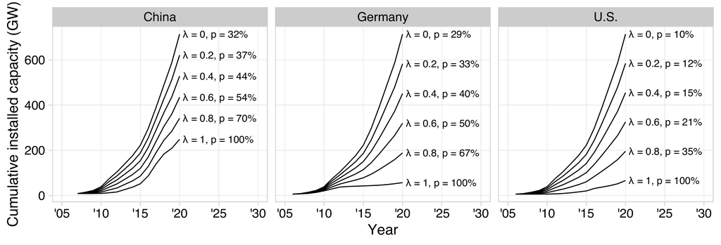

$\lambda$: share of additional capacity from domestic production  
p: share of total capacity from domestic production

Source: Helveston, He, and Davidson (2022)

## Alt model 1: cummulative national module production capacity

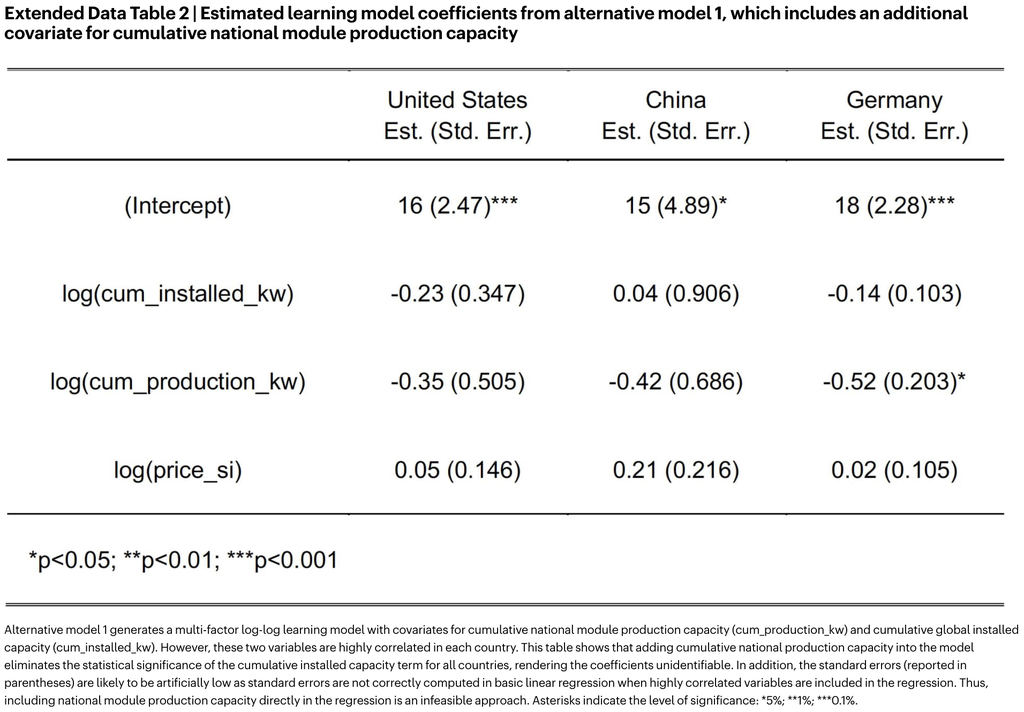

Source: Helveston, He, and Davidson (2022)

## Alt model 2: cumulative national installed capacity

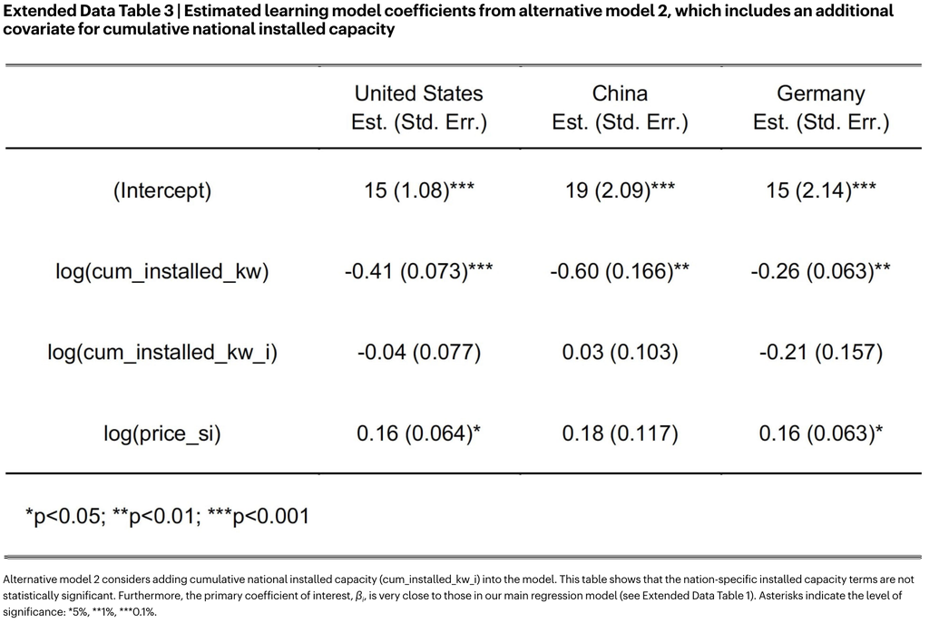

Source: Helveston, He, and Davidson (2022)

## Alt model 3: global weighted average plant size

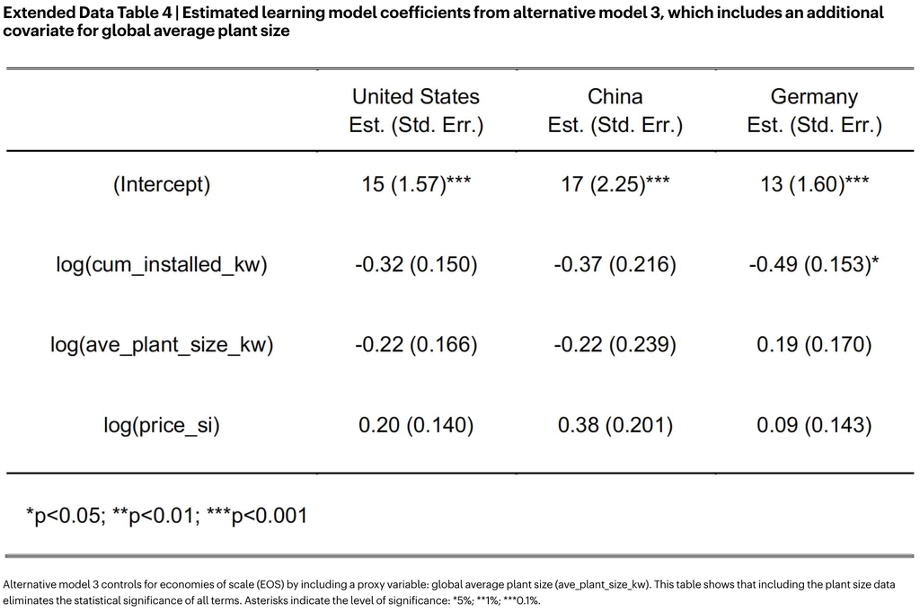

Source: Helveston, He, and Davidson (2022)

### References

Grübler, Arnulf, Nebojša Nakićenović, and David G Victor. 1999. “Dynamics of Energy Technologies and Global Change.” *Energy Policy* 27 (5): 247–80. https://doi.org/10.1016/S0301-4215(98)00067-6.

Helveston, John, Gang He, and Michael Davidson. 2022. “Quantifying the Cost Savings of Global Solar Photovoltaic Supply Chains.” *Nature*. https://doi.org/10.1038/s41586-022-05316-6.

IEA. 2021. “Net Zero by 2050.” International Energy Agency.

Kavlak, Goksin, James McNerney, and Jessika E. Trancik. 2018. “Evaluating the Causes of Cost Reduction in Photovoltaic Modules.” *Energy Policy* 123 (December): 700–710. https://doi.org/10.1016/j.enpol.2018.08.015.

Meng, Jing, Rupert Way, Elena Verdolini, and Laura Diaz Anadon. 2021. “Comparing Expert Elicitation and Model-Based Probabilistic Technology Cost Forecasts for the Energy Transition.” *Proceedings of the National Academy of Sciences* 118 (27).

Yelle, Louis E. 1979. “The Learning Curve: Historical Review and Comprehensive Survey.” *Decision Sciences* 10 (2): 302–28. https://doi.org/10.1111/j.1540-5915.1979.tb00026.x.

Zhang, Chao, Liqin Xie, Yueming Qiu, and Shuangtong Wang. 2022. “Learning-by-Manufacturing and Learning-by-Operating Mechanisms Drive Energy Conservation and Emission Reduction in China’s Coal Power Industry.” *Resources, Conservation and Recycling* 186 (November): 106532. https://doi.org/10.1016/j.resconrec.2022.106532.

Zheng, Cheng, and Daniel M. Kammen. 2014. “An Innovation-Focused Roadmap for a Sustainable Global Photovoltaic Industry.” *Energy Policy* 67: 159–69. https://doi.org/10.1016/j.enpol.2013.12.006.

https://drganghe.github.io